# Analysing pubmed abstracts

```r
knitr::opts_chunk$set(cache = TRUE, warning = FALSE, message = FALSE, echo = TRUE)
library(purrr)
```

# Searching and analysing medical literature with R

We have developed a workflow in R to extract abstracts from Pubmed and apply natural language processing techniques to rapidly extract relevant information and analysis.

To assist this we can use the `pubmedAbstractR` function from the `myScrapers` package. This searches pubmed and allows the user to download abstracts directly into R. It is based on the `RISmed` package. It takes a number of arguments:

- *search* - a search term which can be simple or complex (see below)
- *start* - a start data (or year) to begin the search
- *end* - an end data (or year) to complete the search
- *n* - number of abstracts to be downloaded - by default the first 1000 are downloaded
- *keyword* - if set to TRUE will download keywords
- *authors* - if set to TRUE will download authors and author order

## Getting started

For this exercise we need to install the `myScrapers` package as follows:

```r
if(!require("myScrapers"))
devtools::install_git("https://gitlab.phe.gov.uk/packages/myScrapers", force = TRUE)
library(myScrapers)
```

## Example

### Non-specific searching

Let us say we want to search for *machine learning in public health*. We can pass this as a search term to `pubmedAbstractR` as follows. Let’s set n = 1 to begin with.

```r
library(myScrapers)
library(tidyverse)
search <- "machine learning public health"
start <- 2008
end <- 2018
n <- 1


abstracts <- pubmedAbstractR(search = search, start = start, end = end, n = 1)
```

[output not shown]

We can see this gives a non-specific search which would return 9518 abstracts.

### Specific searching

We can make the search more specific to include only those abstracts which have Medical Subject Headings (MeSH) keywords for ‘machine learning’ and ‘public health’.

```r
library(myScrapers)
search <- "machine learning[MeSH] and public health[MeSH]"
start <- 2008
end <- 2018
n <- 1


abstracts <- pubmedAbstractR(search = search, start = start, end = end, n = 1)
```

```
Please wait...Your query is "machine learning"[MeSH Terms] AND "public health"[MeSH Terms] AND 2008[PDAT] : 2018[PDAT]. This returns 5502 abstracts. By default 1000 abstracts are downloaded. You downloaded 1 abstracts. To retrieve more set 'n =' argument to the desired value
```

There are now 5502 abstracts. We will download these for future reference.

```r
library(myScrapers)
search <- "machine learning[MeSH] and public health[MeSH]"
start <- 2008
end <- 2018
n <- 5502


abstracts1 <- pubmedAbstractR(search = search, start = start, end = end, n = n)
```

```
Please wait...Your query is "machine learning"[MeSH Terms] AND "public health"[MeSH Terms] AND 2008[PDAT] : 2018[PDAT]. This returns 5502 abstracts. By default 1000 abstracts are downloaded. You downloaded 5502 abstracts. To retrieve more set 'n =' argument to the desired value
```

Lets download the most recent 10 with associated keywords and authors (NB this may take a few minutes)

```r
library(myScrapers)
search <- "machine learning[MeSH] and public health[MeSH]"
start <- 2008
end <- 2018
n <- 10


abstracts <- pubmedAbstractR(search = search, start = start, end = end, n = n, authors = TRUE, keyword = TRUE)
```

```
Please wait...Your query is "machine learning"[MeSH Terms] AND "public health"[MeSH Terms] AND 2008[PDAT] : 2018[PDAT]. This returns 5499 abstracts. By default 1000 abstracts are downloaded. You downloaded 10 abstracts. To retrieve more set 'n =' argument to the desired value
```

```r
abstracts
```

| title | abstract | journal | DOI | year | keyword | LastName | Initials | order |
| --- | --- | --- | --- | --- | --- | --- | --- | --- |
| The Tension Between Big Data and Theory in the &quot;Omics&quot; Era of Biomedical Research. |  | Perspectives in biology and medicine | 30613031 | 2019 | Algorithms | Huang | S | 1 |
| The Tension Between Big Data and Theory in the &quot;Omics&quot; Era of Biomedical Research. |  | Perspectives in biology and medicine | 30613031 | 2019 | Biomedical Research | Huang | S | 1 |
| The Tension Between Big Data and Theory in the &quot;Omics&quot; Era of Biomedical Research. |  | Perspectives in biology and medicine | 30613031 | 2019 | methods | Huang | S | 1 |
| The Tension Between Big Data and Theory in the &quot;Omics&quot; Era of Biomedical Research. |  | Perspectives in biology and medicine | 30613031 | 2019 | trends | Huang | S | 1 |
| The Tension Between Big Data and Theory in the &quot;Omics&quot; Era of Biomedical Research. |  | Perspectives in biology and medicine | 30613031 | 2019 | Computational Biology | Huang | S | 1 |
| The Tension Between Big Data and Theory in the &quot;Omics&quot; Era of Biomedical Research. |  | Perspectives in biology and medicine | 30613031 | 2019 | methods | Huang | S | 1 |
| The Tension Between Big Data and Theory in the &quot;Omics&quot; Era of Biomedical Research. |  | Perspectives in biology and medicine | 30613031 | 2019 | trends | Huang | S | 1 |
| The Tension Between Big Data and Theory in the &quot;Omics&quot; Era of Biomedical Research. |  | Perspectives in biology and medicine | 30613031 | 2019 | Data Mining | Huang | S | 1 |
| The Tension Between Big Data and Theory in the &quot;Omics&quot; Era of Biomedical Research. |  | Perspectives in biology and medicine | 30613031 | 2019 | Electronic Health Records | Huang | S | 1 |
| The Tension Between Big Data and Theory in the &quot;Omics&quot; Era of Biomedical Research. |  | Perspectives in biology and medicine | 30613031 | 2019 | Genome-Wide Association Study | Huang | S | 1 |

[output cut: 990 more lines]

or the most recent 3000 with keywords

```r
search <- "machine learning[MeSH] and public health[MeSH]"
start <- 2008
end <- 2019
n <- 3000


abstracts_kw <- pubmedAbstractR(search = search, start = start, end = end, n = n, authors = FALSE, keyword = TRUE)
```

```
Please wait...Your query is "machine learning"[MeSH Terms] AND "public health"[MeSH Terms] AND 2008[PDAT] : 2019[PDAT]. This returns 5499 abstracts. By default 1000 abstracts are downloaded. You downloaded 3000 abstracts. To retrieve more set 'n =' argument to the desired value
```

```r
abstracts_kw
```

| title | abstract | journal | DOI | year | keyword |
| --- | --- | --- | --- | --- | --- |
| The Tension Between Big Data and Theory in the &quot;Omics&quot; Era of Biomedical Research. |  | Perspectives in biology and medicine | 30613031 | 2019 | Algorithms |
| The Tension Between Big Data and Theory in the &quot;Omics&quot; Era of Biomedical Research. |  | Perspectives in biology and medicine | 30613031 | 2019 | Biomedical Research |
| The Tension Between Big Data and Theory in the &quot;Omics&quot; Era of Biomedical Research. |  | Perspectives in biology and medicine | 30613031 | 2019 | methods |
| The Tension Between Big Data and Theory in the &quot;Omics&quot; Era of Biomedical Research. |  | Perspectives in biology and medicine | 30613031 | 2019 | trends |
| The Tension Between Big Data and Theory in the &quot;Omics&quot; Era of Biomedical Research. |  | Perspectives in biology and medicine | 30613031 | 2019 | Computational Biology |
| The Tension Between Big Data and Theory in the &quot;Omics&quot; Era of Biomedical Research. |  | Perspectives in biology and medicine | 30613031 | 2019 | methods |
| The Tension Between Big Data and Theory in the &quot;Omics&quot; Era of Biomedical Research. |  | Perspectives in biology and medicine | 30613031 | 2019 | trends |
| The Tension Between Big Data and Theory in the &quot;Omics&quot; Era of Biomedical Research. |  | Perspectives in biology and medicine | 30613031 | 2019 | Data Mining |
| The Tension Between Big Data and Theory in the &quot;Omics&quot; Era of Biomedical Research. |  | Perspectives in biology and medicine | 30613031 | 2019 | Electronic Health Records |
| The Tension Between Big Data and Theory in the &quot;Omics&quot; Era of Biomedical Research. |  | Perspectives in biology and medicine | 30613031 | 2019 | Genome-Wide Association Study |

[output cut: 990 more lines]

## Simple analysis

### Abstracts per journal

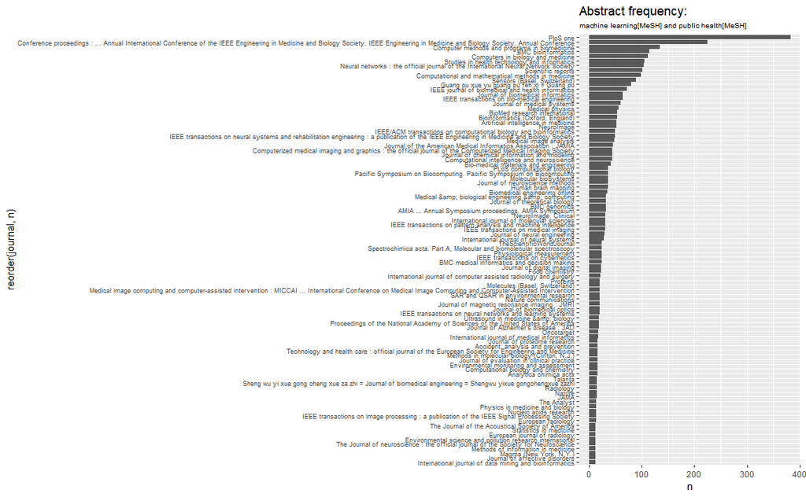

```r
abstracts1 %>%
  group_by(journal) %>%
  count() %>%
  dplyr::filter(n > 10) %>%
  #spread(year, n, fill = 0) %>%
  ggplot(aes(reorder(journal, n), n)) +
  geom_col() +
    coord_flip() +
  labs(title = "Abstract frequency: ",
       subtitle =  search) +
  theme(plot.subtitle = element_text(size = rel(.7)),
        axis.text.y = element_text(size = 7))
```

## Mesh terms

We can look at the most frequently used Mesh terms.

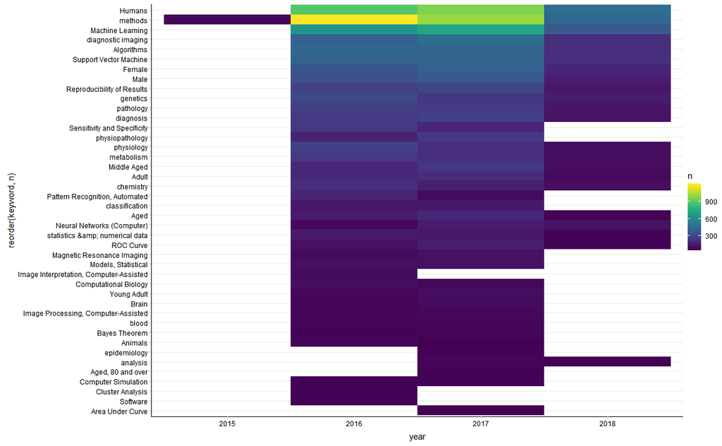

```r
mesh <- abstracts_kw %>%
  count(keyword, year)
mesh %>%
  top_n(100) %>%
  arrange(-n) %>%
  ggplot(aes(year, reorder(keyword, n), fill = n)) +
  geom_tile() +
  phecharts::theme_phe() +
  viridis::scale_fill_viridis()
```

## Wordcloud

A simple way of visualising the abstracts is to *tokenise* them into 1 and 2 ngrams and then plot occurrence frequency as a wordcloud. We can easily do this with the `quanteda` pacakge.

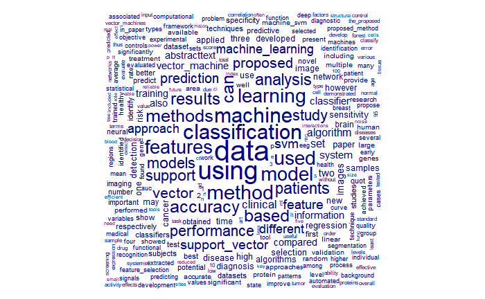

```r
library(quanteda)
abstracts1$abstract <- tm::removeWords(abstracts1$abstract, stopwords("english"))
abs_corpus <- corpus(abstracts1$abstract)
abs_dfm <- dfm(abs_corpus, remove = stopwords("en"), ngrams = 1:2, remove_punct = TRUE)
textplot_wordcloud(abs_dfm )
```

This confirms support vector machines (SVM) as a widely used algorithm and classification and prediction as a common application. It is hard to discern any common public health themes - most of the terms seem to relate to methods.

### Dictionary searching of abstracts

We can create a list of terms of interest and use the to find which abstracts they occur in and how often.

```r
abs_dict <- dictionary(list(ai = c("artificial_intelligence", "ai"),
                            obesity = "obes*",
                            tobacco = c("smok*", "tobacco", "cigar*"),
                            heart_disease = c("heart", "cardi*"),
                            diabetes = "diabet*",
                            cancer = "cancer*" ,
                            svm = "support_vector*",
                            rf = "random_forest",
                            nn = "neural_network*",
                            ph = "public_health",
                            regr = c("regression", "xgb*", "gbm",  "lasso", "glmnet*", "penalised*"),
                            cluster = c("cluster*", "kmeans", "k-means", "hierarchical clus*")
                            ))
abs_dict
```

```
Dictionary object with 12 key entries.
- [ai]:
  - artificial_intelligence, ai
- [obesity]:
  - obes*
- [tobacco]:
  - smok*, tobacco, cigar*
- [heart_disease]:
  - heart, cardi*
- [diabetes]:
  - diabet*
- [cancer]:
  - cancer*
- [svm]:
  - support_vector*
- [rf]:
  - random_forest
- [nn]:
  - neural_network*
- [ph]:
  - public_health
- [regr]:
  - regression, xgb*, gbm, lasso, glmnet*, penalised*
- [cluster]:
  - cluster*, kmeans, k-means, hierarchical clus*
```

## Clustering articles

```r
lookup <- dfm_lookup(abs_dfm, dictionary = abs_dict)
lu1 <- lookup %>%
  convert(., to = "data.frame") %>%
  gather(theme, value, 2:ncol(.)) %>%
  #filter(value > 0, theme %in% c("rf", "ph")) %>%
  spread(theme, value, fill = 0) %>%
  dplyr::filter( cluster> 0, ph >0)
lu1
```

| document | ai | cancer | cluster | diabetes | heart_disease | nn | obesity | ph | regr | rf | svm | tobacco |
| --- | --- | --- | --- | --- | --- | --- | --- | --- | --- | --- | --- | --- |
| text1440 | 0 | 0 | 10 | 0 | 0 | 0 | 0 | 2 | 0 | 0 | 0 | 0 |
| text199 | 0 | 0 | 8 | 0 | 0 | 0 | 0 | 2 | 0 | 0 | 0 | 0 |
| text5005 | 0 | 0 | 3 | 0 | 0 | 0 | 0 | 1 | 0 | 0 | 0 | 0 |
| text723 | 0 | 0 | 6 | 0 | 0 | 2 | 0 | 2 | 0 | 0 | 2 | 0 |

```r
docvars(abs_corpus, "year") <- abstracts1$year
docvars(abs_corpus, "title") <- abstracts1$title
docvars(abs_corpus, "journal") <- abstracts1$journal
docvars(abs_corpus, "doi") <- abstracts1$DOI


corp_df <- docvars(abs_corpus) %>%
  rownames_to_column("document")

lu1 %>%
  #sample_frac(.5) %>%
  left_join(corp_df) %>%
  arrange(doi) %>%
  select(-document) %>%
  distinct()
```

[output not shown]

## Explore article content

We can use text mining techniques to extract information from articles either in pdf or web form. For example there is a useful table about the applications of deep learning in public health in https://ieeexplore.ieee.org/stamp/stamp.jsp?tp=&arnumber=7801947.

We can (attempt) to extract the relevant table from the pdf version using the `tabulizer` package or extract information from web pages

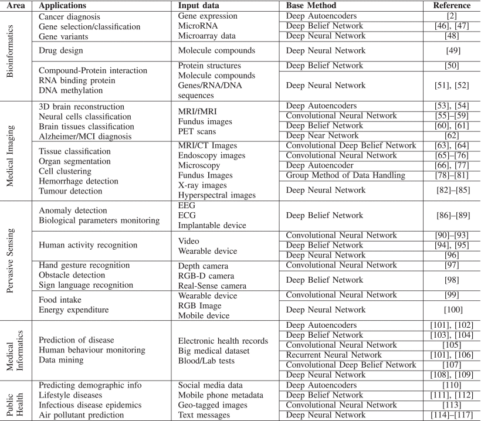